# Customer Churn Modeling

Se nos suministra un conjunto de datos cualitativos y cuantitativos de clientes de una empresa de telecomunicaciones india. El objetivo es es encontrar las acciones concretas que nos ayuden a prevenir que un cliente haga churn (abandone la empres). Para ello, vamos a utilizar las técnicas estadísticas y de modelado de datos hasta ahora en la asignatura.

## Load Data and Libraries

Aquí se cargan las librerías necesarias y el conjunto de datos.

```python
import pandas as pd
import numpy as np

# Libraries of visualization
import matplotlib.pyplot as plt
import seaborn as sns

# Set options
pd.set_option('display.max_columns', None)
sns.set_style('darkgrid')

# Seed used for reproducibility
SEED = 2026
```

```python
# Load data in csv format
data = pd.read_csv('../data/customer_churn_data.csv')
```

## 1. Analisis exploratorio de los datos (EDA)

En esta sección vamos a relaizar un análisis exploratorio de los datos para entender mejor como están compuestas las vairbles. Además realizaremos un análisis de estadística descriptiva y de calidad general de los datos. Crearemos visualizaciones de datos para entender mejor las relaciones entre las variables y entender su distribución. Preliminarmente, se nos ha suministrado una descripción de cada una de las variables, que se muestran a continuación:

- `device` user’s – device brand (Categorical)
- `first_payment_amount` – user’s first payment amount(Numeric)
- `age` – user’s age(Numeric or categorical?)
- `city` – user’s city(Categorical)
- `number_of_cards` – #of cards user owns
- `payments_initiated` – #of payments initiated by user
- `payments_failed` – #of payments failed
- `payments_completed` – #of payments completed
- `payments_completed_amount_first_7days` – amt of payment completed in first 7 days of joining
- `reward_purchase_count_first_7days` – #of rewards claimed in first 7 days
- `coins_redeemed_first_7days` – coins redeemed in first 7 days
- `is_referral` – is user a referred user
- `visits_feature_1` – #of visits made by user to product feature 1
- `visits_feature_2` – #of visits made by user to product feature 2
- `given_permission_1` – has user given permission 1
- `given_permission_2` – has user given permission 2
- `user_id` – user identifier
- `is_churned` – whether user churned

`is_churned` es la variable objetivo, que indica si el cliente ha abandonado o no la empresa. El resto de las variables son carácteristicas de los clientes.

Ya tenemos cargado los datos, veamos que dimensiones tienen y que tipo de variables tenemos en el momento de la carga de los datos.

### 1.1 Shape Data y Análisis descriptivo

Exploremos incialmente los datos para entender su forma y tipo de variables, además de su distribucion y calidad general.

```python
# Shape of data
print(f'Shape of data (rows, columns): {data.shape}\n')
# Data types of columns
print(f'Data types of columns:\n{data.info()}\n')
```

```
Shape of data (rows, columns): (104143, 18)

<class 'pandas.core.frame.DataFrame'>
RangeIndex: 104143 entries, 0 to 104142
Data columns (total 18 columns):
 #   Column                                 Non-Null Count   Dtype
---  ------                                 --------------   -----
 0   device                                 104025 non-null  object
 1   first_payment_amount                   104143 non-null  int64
 2   age                                    104001 non-null  float64
 3   city                                   98301 non-null   object
 4   number_of_cards                        103671 non-null  float64
 5   payments_initiated                     103671 non-null  float64
 6   payments_failed                        103671 non-null  float64
 7   payments_completed                     103671 non-null  float64
 8   payments_completed_amount_first_7days  103671 non-null  float64
 9   reward_purchase_count_first_7days      80879 non-null   float64
 10  coins_redeemed_first_7days             103671 non-null  float64
 11  is_referral                            104143 non-null  bool
 12  visits_feature_1                       101497 non-null  float64
 13  visits_feature_2                       101497 non-null  float64
 14  given_permission_1                     104143 non-null  int64
 15  given_permission_2                     104143 non-null  int64
 16  user_id                                104143 non-null  int64
 17  is_churned                             104143 non-null  int64
dtypes: bool(1), float64(10), int64(5), object(2)
memory usage: 13.6+ MB
Data types of columns:
None
```

```python
# Summary of missing values
missing_values = data.isnull().sum().sort_values(ascending=False)
missing_values = np.round(missing_values /  len(data) * 100, 2)
missing_values = missing_values[missing_values > 0]
missing_values.columns = ['Missing Values (%)']
# Convert to string with percentage format
missing_values = missing_values.apply(lambda x: f'{x}%')
print(f'Missing values in each column:\n{missing_values}\n')
```

```
Missing values in each column:
reward_purchase_count_first_7days        22.34%
city                                      5.61%
visits_feature_1                          2.54%
visits_feature_2                          2.54%
number_of_cards                           0.45%
payments_initiated                        0.45%
payments_failed                           0.45%
payments_completed                        0.45%
payments_completed_amount_first_7days     0.45%
coins_redeemed_first_7days                0.45%
age                                       0.14%
device                                    0.11%
dtype: object
```

Veamos ahora como estan las variables continuas en una exploración rapida de su estadística descriptiva.

#### 1.1.1 Estadística descriptiva de variables numéricas

```python
# Descriptive statistics of numerical variables
data.describe()
```

|  | first_payment_amount | age | number_of_cards | payments_initiated | payments_failed | payments_completed | payments_completed_amount_first_7days | reward_purchase_count_first_7days | coins_redeemed_first_7days | visits_feature_1 | visits_feature_2 | given_permission_1 | given_permission_2 | user_id | is_churned |
| --- | --- | --- | --- | --- | --- | --- | --- | --- | --- | --- | --- | --- | --- | --- | --- |
| count | 104143.000000 | 104001.000000 | 103671.000000 | 103671.000000 | 103671.000000 | 103671.000000 | 103671.000000 | 80879.000000 | 103671.000000 | 101497.000000 | 101497.000000 | 104143.000000 | 104143.000000 | 104143.000000 | 104143.000000 |
| mean | 34.771353 | 32.688291 | 1.989148 | 2.847402 | 0.439940 | 1.830676 | 55.965381 | 2.042075 | 22.494102 | 0.239643 | 0.126861 | 0.852318 | 0.723332 | 251829.347273 | 0.286808 |
| std | 73.181032 | 7.821752 | 1.871436 | 4.223077 | 1.061101 | 3.210357 | 130.720128 | 3.731290 | 64.122134 | 0.624616 | 0.445573 | 0.354786 | 0.447353 | 146009.671697 | 0.452273 |
| min | 0.000000 | 20.000000 | 0.000000 | 1.000000 | 0.000000 | 1.000000 | 0.000000 | 0.000000 | 0.000000 | 0.000000 | 0.000000 | 0.000000 | 0.000000 | 0.000000 | 0.000000 |
| 25% | 2.000000 | 27.000000 | 1.000000 | 1.000000 | 0.000000 | 1.000000 | 3.000000 | 0.000000 | 0.000000 | 0.000000 | 0.000000 | 1.000000 | 0.000000 | 124478.500000 | 0.000000 |
| 50% | 12.000000 | 31.000000 | 1.000000 | 2.000000 | 0.000000 | 1.000000 | 21.000000 | 1.000000 | 3.000000 | 0.000000 | 0.000000 | 1.000000 | 1.000000 | 252377.000000 | 0.000000 |
| 75% | 37.000000 | 36.000000 | 3.000000 | 3.000000 | 0.000000 | 2.000000 | 64.000000 | 3.000000 | 20.000000 | 0.000000 | 0.000000 | 1.000000 | 1.000000 | 378186.500000 | 1.000000 |
| max | 4370.000000 | 80.000000 | 30.000000 | 359.000000 | 30.000000 | 337.000000 | 11107.000000 | 304.000000 | 8857.000000 | 17.000000 | 23.000000 | 1.000000 | 1.000000 | 503533.000000 | 1.000000 |

```python
# Visualize percentiles by numeric variable
data_numeric = data.drop(['given_permission_1', 'given_permission_2', 'user_id', 'is_churned'], axis=1).select_dtypes(include=['int64', 'float64']).copy()
max_values = []
for i, column in enumerate(data_numeric.columns):
    p = data_numeric[column].quantile([0.25, 0.5, 0.75, 0.90, 0.95, 0.99]).to_frame()
    if i == 0:
        percentiles = p.copy()
    else:
        percentiles = pd.concat([percentiles, p], axis=1)

max_values = {col: data_numeric[col].max() for col in data_numeric.columns}
max_values = pd.DataFrame(max_values, index=['max'])
percentiles = pd.concat([percentiles, max_values], axis=0)
percentiles
```

|  | first_payment_amount | age | number_of_cards | payments_initiated | payments_failed | payments_completed | payments_completed_amount_first_7days | reward_purchase_count_first_7days | coins_redeemed_first_7days | visits_feature_1 | visits_feature_2 |
| --- | --- | --- | --- | --- | --- | --- | --- | --- | --- | --- | --- |
| 0.25 | 2.0 | 27.0 | 1.0 | 1.0 | 0.0 | 1.0 | 3.0 | 0.0 | 0.0 | 0.0 | 0.0 |
| 0.5 | 12.0 | 31.0 | 1.0 | 2.0 | 0.0 | 1.0 | 21.0 | 1.0 | 3.0 | 0.0 | 0.0 |
| 0.75 | 37.0 | 36.0 | 3.0 | 3.0 | 0.0 | 2.0 | 64.0 | 3.0 | 20.0 | 0.0 | 0.0 |
| 0.9 | 88.0 | 42.0 | 4.0 | 6.0 | 1.0 | 3.0 | 141.0 | 4.0 | 70.0 | 1.0 | 1.0 |
| 0.95 | 143.0 | 49.0 | 6.0 | 8.0 | 2.0 | 4.0 | 218.0 | 6.0 | 103.0 | 1.0 | 1.0 |
| 0.99 | 323.0 | 60.0 | 9.0 | 17.0 | 5.0 | 11.0 | 490.0 | 13.0 | 237.0 | 3.0 | 2.0 |
| max | 4370.0 | 80.0 | 30.0 | 359.0 | 30.0 | 337.0 | 11107.0 | 304.0 | 8857.0 | 17.0 | 23.0 |

Existen variables de tipo `int64` que en realidad son variables categóricas (0 o 1). Estas variables son `given_permission_1` y `given_permission_2`. Excluimos `user_id` del análisis ya que se trata únicamente de un identificador único para cada usuario. Por tanto, las trataremos como variables categóricas en esta fase exploratoria más adelante.

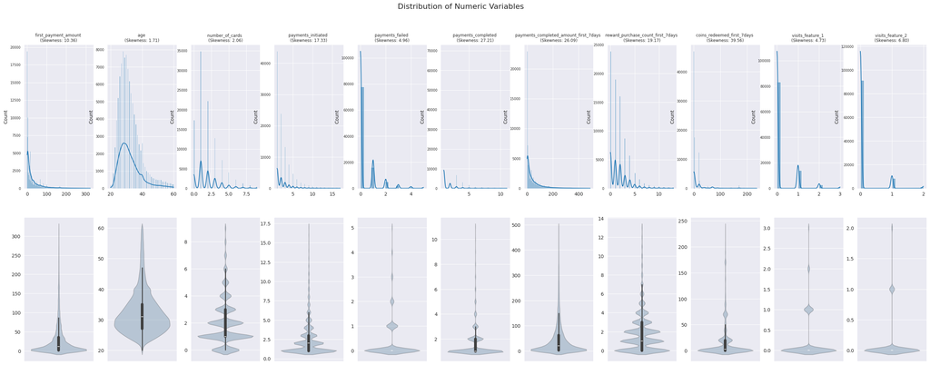

```python
# Only data numeric
data_numeric = data.drop(['given_permission_1', 'given_permission_2', 'user_id', 'is_churned'], axis=1).select_dtypes(include=['int64', 'float64']).copy()

# Create Canva with matplotlib and seaborn
fig, ax = plt.subplots(2, 11, figsize=(34, 12))

# Loop through each numeric column and create a histogram
for i, column in enumerate(data_numeric.columns):
    # Hist Plot with KDE
    series = data_numeric[data_numeric[column] <= data_numeric[column].quantile(0.99)][column]
    # Calculate Skewness
    skewness = data_numeric[column].skew()
    sns.histplot(
        series, kde=True, ax=ax[0, i], stat = 'count'
    )
    ax[0, i].set_title(f'{column} \n(Skewness: {skewness:.2f})', fontsize = 8.5)
    ax[0, i].set_xlabel('')
    # reduce y-axis label size
    ax[0, i].tick_params(axis='y', labelsize=7)

    # Violin Plot
    sns.violinplot(series, orient='v', ax=ax[1, i], saturation = 0.5, alpha = 0.3)
    ax[1, i].set_ylabel("")

plt.suptitle('Distribution of Numeric Variables', fontsize=16)

plt.show()
```

Al restringir la visualización de las variables numéricas hasta el percentil 99, se observa con mayor claridad su distribución.

```python
data.describe()
```

|  | first_payment_amount | age | number_of_cards | payments_initiated | payments_failed | payments_completed | payments_completed_amount_first_7days | reward_purchase_count_first_7days | coins_redeemed_first_7days | visits_feature_1 | visits_feature_2 | given_permission_1 | given_permission_2 | user_id | is_churned |
| --- | --- | --- | --- | --- | --- | --- | --- | --- | --- | --- | --- | --- | --- | --- | --- |
| count | 104143.000000 | 104001.000000 | 103671.000000 | 103671.000000 | 103671.000000 | 103671.000000 | 103671.000000 | 80879.000000 | 103671.000000 | 101497.000000 | 101497.000000 | 104143.000000 | 104143.000000 | 104143.000000 | 104143.000000 |
| mean | 34.771353 | 32.688291 | 1.989148 | 2.847402 | 0.439940 | 1.830676 | 55.965381 | 2.042075 | 22.494102 | 0.239643 | 0.126861 | 0.852318 | 0.723332 | 251829.347273 | 0.286808 |
| std | 73.181032 | 7.821752 | 1.871436 | 4.223077 | 1.061101 | 3.210357 | 130.720128 | 3.731290 | 64.122134 | 0.624616 | 0.445573 | 0.354786 | 0.447353 | 146009.671697 | 0.452273 |
| min | 0.000000 | 20.000000 | 0.000000 | 1.000000 | 0.000000 | 1.000000 | 0.000000 | 0.000000 | 0.000000 | 0.000000 | 0.000000 | 0.000000 | 0.000000 | 0.000000 | 0.000000 |
| 25% | 2.000000 | 27.000000 | 1.000000 | 1.000000 | 0.000000 | 1.000000 | 3.000000 | 0.000000 | 0.000000 | 0.000000 | 0.000000 | 1.000000 | 0.000000 | 124478.500000 | 0.000000 |
| 50% | 12.000000 | 31.000000 | 1.000000 | 2.000000 | 0.000000 | 1.000000 | 21.000000 | 1.000000 | 3.000000 | 0.000000 | 0.000000 | 1.000000 | 1.000000 | 252377.000000 | 0.000000 |
| 75% | 37.000000 | 36.000000 | 3.000000 | 3.000000 | 0.000000 | 2.000000 | 64.000000 | 3.000000 | 20.000000 | 0.000000 | 0.000000 | 1.000000 | 1.000000 | 378186.500000 | 1.000000 |
| max | 4370.000000 | 80.000000 | 30.000000 | 359.000000 | 30.000000 | 337.000000 | 11107.000000 | 304.000000 | 8857.000000 | 17.000000 | 23.000000 | 1.000000 | 1.000000 | 503533.000000 | 1.000000 |

#### 1.1.2 Estadistica descriptiva de variables categóricas

Veamos ahora la estadística descriptiva de las variables categóricas.

- `device`: Marca del dispositivo
- `city`: Ciudad del usuario
- `is_referral`: Si el usuario es referido o no (binaria)
- `given_permission_1`: Si el usuario ha dado el permiso 1 (binaria)
- `given_permission_2`: Si el usuario ha dado el permiso 2 (binaria)

Veremos un preliminar de existe una relación directa con la variable `is_churned`. ¿La distribución cambia según si churnea o no?. Haremos un `countplot` o `barplot` de frecuencias y para la relacion de churn haremos un grouped. Finalmente un churn relationship con `crosstab` + visualizacion.

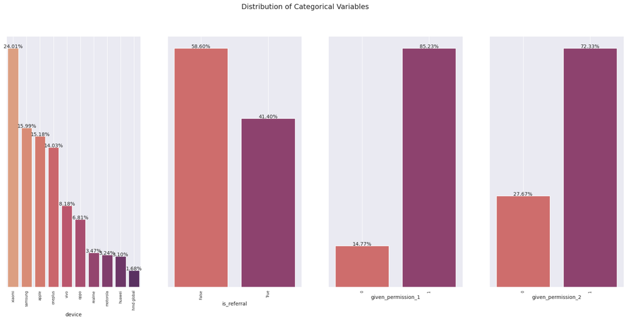

```python
# Categories
cat_vars = ['device', 'is_referral', 'given_permission_1', 'given_permission_2']

fig, ax = plt.subplots(1, 4, figsize=(22, 9))

for idx, col in enumerate(cat_vars):
    counts = data[col].value_counts().head(10)
    sns.barplot(x = counts.index, y = counts.values, ax=ax[idx], hue = counts.index, dodge = False, palette = 'flare', legend = False)
    # remove y ticks
    ax[idx].set_yticks([])
    ax[idx].tick_params(axis='x', labelsize=7, rotation = 90)
    ax[idx].grid(True)

    # set lebels over bars
    for p in ax[idx].patches:
        height = p.get_height()
        ax[idx].text(p.get_x() + p.get_width() / 2., height + 3, f'{int(height)/len(data)*100:.2f}%', ha="center", fontsize=10)

plt.suptitle('Distribution of Categorical Variables', fontsize=14)

plt.show()
```

Realizando un top 10 de las marcas de dispositivos vemos como en su mayoría son marcas que ya concentran una gran cuota. Vemos que una buena parte de los usuarios utilizan dispositivos de la marca Xiomi, seguido por Samsung, Apple y Oneplus. Vemos además que una buena parte de los usuarios se encuentran referidos, más de lo que podríamos pensar, representando un 41.4% del total de usuarios, mas adelante vemos si existe una relación entre `is_referral` y `is_churned`.

`given_permission_1` y `given_permission_2` vemos que un gran peso de los usuarios han dado ambos permisos, siendo el permiso 1 con un 85.23% una gran mayoría y el permiso 2 con 72.33% que también representa una gran mayoría.

```python
from plotly.subplots import make_subplots
import plotly.graph_objects as go

permission_vars = ['is_referral', 'given_permission_1', 'given_permission_2']
color_map = {'0': '#1f3b82', '1': '#f2c500'}

fig = make_subplots(
    rows=1,
    cols=3,
    shared_yaxes=True,
    horizontal_spacing=0.05,
    subplot_titles=permission_vars
)

for col, permission_var in enumerate(permission_vars, start=1):
    grouped = (
        data.groupby([permission_var, 'is_churned'])['user_id']
        .count()
        .reset_index()
    )

    grouped[permission_var] = grouped[permission_var].astype(str)
    grouped['is_churned'] = grouped['is_churned'].astype(str)

    grouped['total_x'] = grouped.groupby(permission_var)['user_id'].transform('sum')
    grouped['pct'] = grouped['user_id'] / grouped['total_x'] * 100

    for churn_value in ['0', '1']:
        d = grouped[grouped['is_churned'] == churn_value].sort_values(permission_var)

        fig.add_trace(
            go.Bar(
                x=d[permission_var],
                y=d['user_id'],
                name=f'is_churned={churn_value}',
                marker_color=color_map[churn_value],
                text=d['pct'].map(lambda x: f'{x:.2f}%'),
                textposition='inside',
                showlegend=(col == 1)  # leyenda solo una vez
            ),
            row=1,
            col=col
        )

    fig.update_xaxes(title_text=permission_var, row=1, col=col)

fig.update_yaxes(title_text='user_id', row=1, col=1)
fig.update_layout(
    barmode='stack',
    width=1500,
    height=500,
    title='Distribution by Churn Status',
    bargap=0.2
)

fig.show(config={'displayModeBar': False}, renderer = 'notebook')
```

[interactive chart not shown]

Es curioso, parece ser que los usuarios referidos tienen mayor probabilidad de churnear que los no referidos, con un RR de 1.410, contrario a lo que esperaríamos. En el caso de los permisos el patron es claro, es mucho mas probable que un usuario churnee si no ha dado los permisos, siendo el permiso dos aun mas critico. $RR_{p1} = 1.38$ y $RR_{p2} = 1.47$. Parece ser critico que los usuarios den el permiso 2.

Ahora exploremos que pasa con la variable de `device` para ver si existen correlaciones con `is_chuned`. Por un lado podemos hacer el análisis del top 10 marcas pero también vamos a aprovechar para realizar el análisis de si es o no un dispositvo android o iOS, lo cuál será sencillo de determinar ya que solo Apple es iOS y el resto son potencialmente Android.

```python
fig = make_subplots(
    rows=1,
    cols=2,
    horizontal_spacing=0.05,
    subplot_titles=('Top 10 Device Brands', 'Device Type')
)

data_plot = data.copy()
data_plot['device_type'] = np.where(
    data_plot['device'].eq('apple'),
    'iOS',
    'Android'
 )

grouped_device = (
    data_plot.groupby(['device', 'is_churned'])['user_id']
    .count()
    .reset_index()
 )
grouped_device_type = (
    data_plot.groupby(['device_type', 'is_churned'])['user_id']
    .count()
    .reset_index()
 )

grouped_device['is_churned'] = grouped_device['is_churned'].astype(str)
grouped_device_type['is_churned'] = grouped_device_type['is_churned'].astype(str)

total_grouped_device = grouped_device.groupby('device')['user_id'].transform('sum')
grouped_device['pct'] = grouped_device['user_id'] / total_grouped_device * 100

total_grouped_device_type = grouped_device_type.groupby('device_type')['user_id'].transform('sum')
grouped_device_type['pct'] = grouped_device_type['user_id'] / total_grouped_device_type * 100

top_devices = data_plot['device'].value_counts().head(10).index.tolist()
grouped_device_top = grouped_device[grouped_device['device'].isin(top_devices)].copy()

color_map = {'0': '#1f3b82', '1': '#f2c500'}

for churn_value in ['0', '1']:
    d_device = grouped_device_top[grouped_device_top['is_churned'] == churn_value].copy()
    d_device['device'] = pd.Categorical(d_device['device'], categories=top_devices, ordered=True)
    d_device = d_device.sort_values('device')

    fig.add_trace(
        go.Bar(
            x=d_device['device'],
            y=d_device['user_id'],
            name=f'is_churned={churn_value}',
            marker_color=color_map[churn_value],
            text=d_device['pct'].map(lambda x: f'{x:.2f}%'),
            textposition='inside',
            showlegend=True
        ),
        row=1,
        col=1
    )

    d_type = grouped_device_type[grouped_device_type['is_churned'] == churn_value].copy()
    d_type['device_type'] = pd.Categorical(d_type['device_type'], categories=['Android', 'iOS'], ordered=True)
    d_type = d_type.sort_values('device_type')

    fig.add_trace(
        go.Bar(
            x=d_type['device_type'],
            y=d_type['user_id'],
            name=f'is_churned={churn_value}',
            marker_color=color_map[churn_value],
            text=d_type['pct'].map(lambda x: f'{x:.2f}%'),
            textposition='inside',
            showlegend=False
        ),
        row=1,
        col=2
    )

fig.update_xaxes(title_text='device', tickangle=45, row=1, col=1)
fig.update_xaxes(title_text='device_type', row=1, col=2)
fig.update_yaxes(title_text='N° Users', row=1, col=1)
fig.update_yaxes(title_text='N° Users', row=1, col=2)

fig.update_layout(
    barmode='stack',
    width=1500,
    height=600,
    title='Churn Distribution by Device and Device Type',
    bargap=0.18
 )

fig.show(config={'displayModeBar': False}, renderer='notebook')
```

[interactive chart not shown]

Aquí resulta interesante observar que los usuarios de Apple presentan una tasa de churn 4.94 puntos porcentuales menor que la de los usuarios de dispositivos Android. Los usuarios de OnePlus también muestran una tasa de churn relativamente baja, mientras que los de VIVO registran una de las más altas dentro del top 10 de dispositivos, con un 39.41%. Esto sugiere que el tipo de dispositivo podría estar relacionado con el churn, posiblemente porque también refleja, de forma indirecta, la capacidad de gasto de los usuarios. En este sentido, disponer de dispositivos de gama alta, como Apple u OnePlus, parece asociarse con una menor probabilidad de abandono.

Samsung, por su parte, ofrece dispositivos tanto de gama alta como de gama media y baja, lo que podría explicar que su tasa de churn se sitúe en un nivel intermedio, más cercano al 31.27%.

Ahora echemos un vistazo a la categoria `city`.

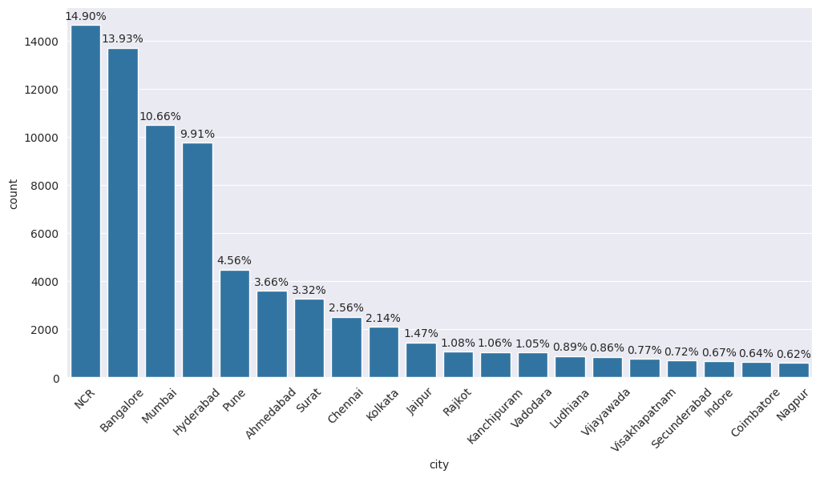

```python
plt.figure(figsize=(12, 6))
sns.barplot(
    data=data.city.value_counts().head(20)
)

# Set labels over bars in percentage of total data
total = data.city.value_counts().sum()
plt.bar_label(plt.gca().containers[0], labels=[f'{(v/total)*100:.2f}%' for v in data.city.value_counts().head(20)], padding=3, fontsize=10)

plt.tick_params(axis='x', labelsize=10, rotation = 45)
```

```python
# Load Data Size and category citizies
city_tiers = pd.read_csv('../data/indian_city_tiers.csv').rename(columns = {"category": "city_category"})

# Merge with data
df = data.merge(city_tiers, on = "city", how='left')
```

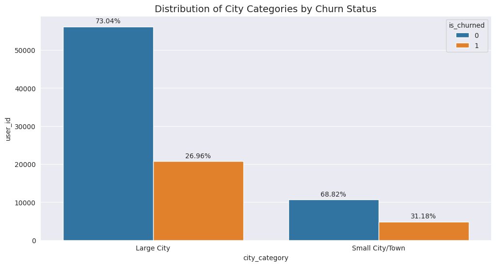

```python
plt.figure(figsize=(12, 6))
city_category_counts = df.groupby(['city_category', 'is_churned'])['user_id'].count().reset_index()
ax = sns.barplot(
    data=city_category_counts,
    x='city_category',
    y='user_id',
    hue='is_churned',
)

# Label bars as percentage within each x-category (not over full dataset)
city_category_counts['pct_within_city_category'] = (
    city_category_counts['user_id']
    / city_category_counts.groupby('city_category')['user_id'].transform('sum')
    * 100
)

x_order = [tick.get_text() for tick in ax.get_xticklabels()]
hue_order = [text.get_text() for text in ax.legend_.texts]
pct_lookup = {
    (str(row['city_category']), str(row['is_churned'])): row['pct_within_city_category']
    for _, row in city_category_counts.iterrows()
}

for hue_idx, container in enumerate(ax.containers):
    hue_value = hue_order[hue_idx]
    labels = []
    for x_idx, _ in enumerate(container):
        x_value = x_order[x_idx]
        pct = pct_lookup.get((str(x_value), str(hue_value)))
        labels.append(f'{pct:.2f}%' if pct is not None else '')
    ax.bar_label(container, labels=labels, padding=3, fontsize=10)

plt.tick_params(axis='x', labelsize=10)
plt.title('Distribution of City Categories by Churn Status', fontsize=14)
plt.show()
```

Preliminarmente, podemos decir que los usuarios en ciudades pequeñas tienen una mayor probabilidad relativa de caer en churn, un riesgo relativo un 15.7% mayor de que un usuario de ciudad grande. Es un hallazgo interesante, y debe ser validado estadísticamente para confirmar su significancia en la siguiente seccion de análisis estadístico.

### 1.2 Features Engineering

En el análisis exploratorio seguimos una secuencia clara. Primero, evaluamos los **missing values** para identificar su magnitud y decidir cómo tratarlos. Después, analizamos las variables numéricas, donde observamos sesgos que hacen necesarias transformaciones para mejorar su distribución y su utilidad en el modelado. Finalmente, revisamos las variables categóricas y planteamos recodificaciones que facilitan su interpretación y uso posterior.

Entre estas recodificaciones destacan dos ejemplos: la variable `device`, transformada en `device_type` para agrupar dispositivos en categorías más generales, y la variable `city`, que permitió diferenciar ciudades grandes y pequeñas para explorar su relación con la probabilidad de churn. En esta fase de **feature engineering** aplicaremos ese mismo orden de trabajo para dejar el dataset preparado para las siguientes etapas de análisis estadístico y modelado predictivo.

```python
# Append Android or iOS based on device
df['device_type'] = np.where(
    df['device'].eq('apple'),
    'iOS',
    'Android'
)
```

#### 1.2.1 Trasnformaciones

Bajo la lista de trasnformaciones planteadas en la sección de análisis descriptivo, aplicamos las siguientes transformaciones:

```python
# Copy DataFrame for transformations
data_t = df.copy()

# First Transformations with boxcox and log
from scipy import stats

columns_to_transform = {
    'first_payment_amount': 'boxcox',
    'payments_initiated': 'log',
    'payments_completed': 'log',
    'payments_failed': 'log',
    'payments_completed_amount_first_7days': 'log',
    'coins_redeemed_first_7days': 'boxcox',
}

for column, method in columns_to_transform.items():
    series = pd.to_numeric(data_t[column], errors='coerce')

    if method == 'boxcox':
        # Box-Cox requires finite and strictly positive values.
        # We add +1 to handle zeros and transform only valid rows.
        shifted = series + 1
        valid_mask = shifted.notna() & np.isfinite(shifted) & (shifted > 0)

        transformed = pd.Series(np.nan, index=data_t.index, dtype='float64')
        if valid_mask.any():
            transformed.loc[valid_mask], _ = stats.boxcox(shifted.loc[valid_mask])
        data_t[column] = transformed

    elif method == 'log':
        # log1p handles zeros; preserve NaN as NaN.
        data_t[column] = np.log1p(series)

# transform to categorical variables with recoding
data_t['visits_feature_1'] = np.where(data_t['visits_feature_1'] > 0, 1, 0)
data_t['visits_feature_2'] = np.where(data_t['visits_feature_2'] > 0, 1, 0)
data_t['reward_purchase_count_first_7days'] = pd.cut(
    data_t['reward_purchase_count_first_7days'],
    bins=[-1, 0, 1, 2, np.inf],
    labels=['0', '1', '2', '>2']
 )


data_t
```

|  | device | first_payment_amount | age | city | number_of_cards | payments_initiated | payments_failed | payments_completed | payments_completed_amount_first_7days | reward_purchase_count_first_7days | coins_redeemed_first_7days | is_referral | visits_feature_1 | visits_feature_2 | given_permission_1 | given_permission_2 | user_id | is_churned | city_category | device_type |
| --- | --- | --- | --- | --- | --- | --- | --- | --- | --- | --- | --- | --- | --- | --- | --- | --- | --- | --- | --- | --- |
| 0 | samsung | 0.000000 | 20.0 | Ahmedabad | 2.0 | 0.693147 | 0.000000 | 0.693147 | 0.000000 | NaN | 0.000000 | False | 1 | 0 | 1 | 0 | 269438 | 0 | Large City | Android |
| 1 | xiaomi | 0.000000 | 20.0 | Surat | 1.0 | 0.693147 | 0.000000 | 0.693147 | 0.000000 | NaN | 0.000000 | True | 0 | 0 | 1 | 0 | 139521 | 0 | Large City | Android |
| 2 | xiaomi | 0.000000 | 20.0 | Kullu | 1.0 | 1.098612 | 0.693147 | 0.693147 | 0.000000 | 0 | 0.000000 | True | 0 | 0 | 0 | 1 | 307352 | 0 | Small City/Town | Android |
| 3 | oneplus | 0.000000 | 20.0 | Mumbai | 2.0 | 1.609438 | 0.693147 | 1.098612 | 5.777652 | 2 | 2.076828 | False | 0 | 0 | 1 | 1 | 456424 | 0 | Large City | Android |
| 4 | apple | 0.000000 | 20.0 | Pune | 2.0 | 0.693147 | 0.000000 | 0.693147 | 0.000000 | 0 | 0.000000 | False | 0 | 1 | 1 | 1 | 398779 | 0 | Large City | iOS |
| ... | ... | ... | ... | ... | ... | ... | ... | ... | ... | ... | ... | ... | ... | ... | ... | ... | ... | ... | ... | ... |
| 104138 | samsung | 3.982857 | NaN | Ongole | 0.0 | 1.386294 | 0.693147 | 1.098612 | 4.043051 | 2 | 2.076828 | True | 0 | 0 | 1 | 0 | 30036 | 1 | Small City/Town | Android |
| 104139 | vivo | 4.172831 | NaN | Chennai | 1.0 | 0.693147 | 0.000000 | 0.693147 | 4.219508 | 2 | 2.443753 | True | 0 | 0 | 1 | 0 | 377399 | 1 | Large City | Android |
| 104140 | apple | 4.172831 | NaN | Bangalore | 3.0 | 1.098612 | 0.000000 | 1.098612 | 4.927254 | NaN | 0.000000 | False | 0 | 0 | 1 | 1 | 8415 | 1 | Large City | iOS |
| 104141 | samsung | 4.379367 | NaN | Hyderabad | 5.0 | 1.386294 | 0.693147 | 1.098612 | 5.356586 | >2 | 2.732232 | False | 0 | 0 | 0 | 1 | 8056 | 1 | Large City | Android |
| 104142 | oneplus | 5.985550 | NaN | Hyderabad | 1.0 | 0.693147 | 0.000000 | 0.693147 | 6.082219 | 0 | 0.000000 | False | 0 | 0 | 1 | 1 | 109558 | 1 | Large City | Android |

104143 rows × 20 columns

Una vez realizado las transformaciones, vamos a ver como se han quedado las distribuciones de las variables en dos filas de visualizaciones para que puedan ser comparados.

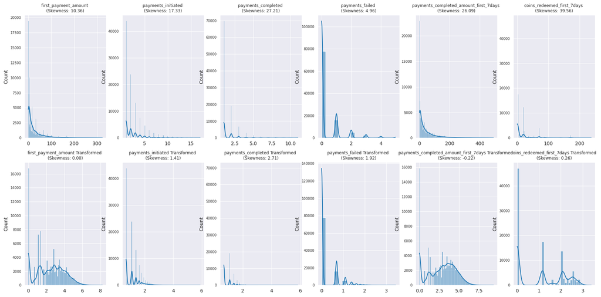

```python
fig, ax = plt.subplots(2, 6, figsize=(21, 10))

for i, key in enumerate(columns_to_transform.keys()):
    # Hist Plot with KDE
    series = data_numeric[data_numeric[key] <= data_numeric[key].quantile(0.99)][key]
    # Calculate Skewness
    skewness = data_numeric[key].skew()
    sns.histplot(
        series, kde=True, ax=ax[0, i], stat = 'count'
    )
    ax[0, i].set_title(f'{key} \n(Skewness: {skewness:.2f})', fontsize = 8.5)
    ax[0, i].set_xlabel('')
    # reduce y-axis label size
    ax[0, i].tick_params(axis='y', labelsize=7)

    # Hist Plot transformed data
    series_t = data_t[key].copy()
    skewness_t = series_t.skew()
    sns.histplot(
        series_t, kde=True, ax=ax[1, i], stat = 'count'
    )
    ax[1, i].set_title(f'{key} Transformed \n(Skewness: {skewness_t:.2f})', fontsize = 8.5)
    ax[1, i].set_xlabel('')
    ax[1, i].tick_params(axis='y', labelsize=7)
```

### 1.3 Conclusiones del EDA

Después de esta fase exploratoria, realizada en varias etapas, se observan distintos puntos de atención tanto en el procesamiento de datos que debe realizarse como en los hallazgos interesantes de correlación entre las variables categóricas y la variable objetivo is_churned.

Se identifican varios valores faltantes que pueden tratarse con relativa facilidad, ya que se concentran en variables con patrones claros y sesgos pronunciados hacia un valor específico; por tanto, su imputación es sencilla. La variable `reward_purchase_count_first_7days` sí puede requerir un tratamiento más cuidadoso, ya que el porcentaje de faltantes es elevado (22,34 %) y no presenta un patrón de concentración tan claro. Por ello, conviene explorar sus correlaciones con otras variables para plantear una imputación adecuada.

En las variables categóricas también se encontraron hallazgos interesantes. Parece que un usuario referido muestra lo contrario a lo esperado: tiene una probabilidad relativa mayor de churn. En el caso de los permisos, el patrón es claro: es mucho más probable que un usuario haga churn si no ha otorgado los permisos, siendo el permiso 2 el más crítico. En cuanto a la variable city, se realizó una investigación rápida para entender el contexto de estas ciudades y se encontró que las ciudades más pequeñas tienen una probabilidad relativa mayor de churn. Todos estos hallazgos son preliminares y deben validarse estadísticamente mediante pruebas como ANOVA, chi-cuadrado y tests de correlación, para confirmar su significancia y plantear acciones concretas sobre estas variables.